# Project2

Nicole, Ali, Sidd, Ryan

3/10/2021

```r
#Time limit set
library(gurobi)
#timelimit = 36000

#reading the csv files
stocks2019 = read.csv("stocks2019.csv", header=T)
stocks2019[1:5,]
```

```
##        X     NDX     ATVI   ADBE   AMD   ALXN   ALGN   GOOGL    GOOG    AMZN
## 1 1/2/19 6360.87 46.35038 224.57 18.83  98.05 202.12 1054.68 1045.85 1539.13
## 2 1/3/19 6147.13 44.70451 215.70 17.05 100.21 184.78 1025.47 1016.06 1500.28
## 3 1/4/19 6422.67 46.48836 226.19 19.00 106.00 186.71 1078.07 1070.71 1575.39
## 4 1/7/19 6488.25 47.79914 229.26 20.57 107.94 189.92 1075.92 1068.39 1629.51
## 5 1/8/19 6551.85 49.24790 232.68 20.75 108.61 192.95 1085.37 1076.28 1656.58
##       AMGN      ADI   ANSS     AAPL     AMAT     ASML   ADSK      ADP   BIDU
## 1 179.8896 82.48642 143.01 38.50502 32.43989 152.4570 128.96 124.4896 162.25
## 2 177.1524 77.50383 137.64 34.66964 30.56016 144.0490 121.85 120.7302 154.71
## 3 183.2081 79.38551 143.66 36.14966 32.65306 150.2819 128.28 125.5419 160.95
## 4 185.6735 79.88472 147.32 36.06920 33.23441 153.7153 132.72 124.8627 162.60
## 5 188.0546 81.83360 148.05 36.75679 31.88759 152.5838 133.87 125.5992 163.40
##     BIIB  BMRN    BKNG     AVGO  CDNS      CDW     CERN   CHTR   CHKP     CTAS
## 1 304.69 84.96 1721.70 233.4727 43.23 77.29257 50.91922 287.99 103.50 163.7994
## 2 307.00 84.20 1663.12 212.7051 41.53 75.30096 49.77066 287.50 102.35 161.1785
```

[output cut: 51 more lines]

```r
stocks2020 = read.csv("stocks2020.csv", header=T)
stocks2020[1:5,]
```

```
##        X     NDX     ATVI   ADBE   AMD   ALXN   ALGN   GOOGL    GOOG    AMZN
## 1 1/2/20 8872.22 58.26679 334.43 49.10 107.84 283.68 1368.68 1367.37 1898.01
## 2 1/3/20 8793.90 58.28666 331.81 48.60 106.41 280.44 1361.52 1360.66 1874.97
## 3 1/6/20 8848.52 59.34967 333.71 48.39 106.58 285.88 1397.81 1394.21 1902.88
## 4 1/7/20 8846.45 59.94575 333.39 48.25 106.85 283.06 1395.11 1393.34 1906.86
## 5 1/8/20 8912.37 59.48875 337.87 47.83 108.58 286.00 1405.04 1404.32 1891.97
##       AMGN      ADI   ANSS     AAPL     AMAT     ASML   ADSK      ADP   BIDU
## 1 231.9176 117.9969 259.59 74.33351 61.37207 300.1398 187.83 166.2757 138.22
## 2 230.3431 115.9198 256.97 73.61084 60.39525 295.3032 184.95 165.9242 133.80
## 3 232.1107 114.5579 254.59 74.19740 59.09282 292.9543 187.12 166.1487 135.94
## 4 229.9278 117.1641 256.67 73.84844 60.79980 296.1358 187.50 164.1377 136.70
## 5 230.1017 118.2223 257.73 75.03638 60.76033 299.2082 189.95 165.6801 137.83
##     BIIB  BMRN    BKNG     AVGO  CDNS      CDW     CERN   CHTR   CHKP     CTAS
## 1 294.24 84.04 2074.58 308.3073 71.44 142.0495 72.82061 490.43 112.26 267.3969
## 2 290.85 84.00 2065.48 300.4655 70.42 140.3415 73.02833 494.47 112.29 266.1921
```

[output cut: 51 more lines]

```r
nc = ncol(stocks2019)
nr = nrow(stocks2019)
#this calculates the return per day (price increase/decrease per day) for 2019
return2019 <- ((stocks2019[2:nr, 2:nc] - stocks2019[1:(nr-1), 2:nc])/stocks2019[1:(nr-1), 2:nc])
return2019[1:5,]
```

```
##            NDX        ATVI        ADBE          AMD        ALXN        ALGN
## 2 -0.033602358 -0.03550922 -0.03949775 -0.094530058 0.022029535 -0.08579060
## 3  0.044824177  0.03990300  0.04863238  0.114369567 0.057778675  0.01044490
## 4  0.010210719  0.02819594  0.01357263  0.082631579 0.018301906  0.01719239
## 5  0.009802350  0.03030927  0.01491755  0.008750608 0.006207143  0.01595408
## 6  0.007454359  0.01721032  0.01181881 -0.026987904 0.012429776  0.03819648
##          GOOGL         GOOG         AMZN         AMGN          ADI         ANSS
## 2 -0.027695682 -0.028483988 -0.025241517 -0.015216067 -0.060404973 -0.037549795
## 3  0.051293530  0.053786157  0.050063978  0.034183442  0.024278490  0.043737322
## 4 -0.001994214 -0.002166736  0.034353395  0.013456871  0.006288478  0.025476840
## 5  0.008783135  0.007384957  0.016612323  0.012823729  0.024396092  0.004955172
## 6 -0.003427376 -0.001505180  0.001714429 -0.001196413  0.025340167  0.017494062
##           AAPL        AMAT         ASML         ADSK           ADP         BIDU
## 2 -0.099607366 -0.05794508 -0.055150393 -0.055133441 -0.0301980823 -0.046471451
## 3  0.042689281  0.06848463  0.043269379  0.052769808  0.0398543291  0.040333461
```

[output cut: 93 more lines]

```r
nc = ncol(stocks2020)
nr = nrow(stocks2020)
#this calculates the return per day (price increase/decrease per day) for 2020
return2020 <- ((stocks2020[2:nr, 2:nc] - stocks2020[1:(nr-1), 2:nc])/stocks2020[1:(nr-1), 2:nc])
return2020[1:5,]
```

```
##             NDX          ATVI          ADBE          AMD         ALXN
## 2 -0.0088274793  0.0003408974 -0.0078342106 -0.010183300 -0.013260312
## 3  0.0062110255  0.0182377081  0.0057261475 -0.004320967  0.001597575
## 4 -0.0002338624  0.0100434762 -0.0009588445 -0.002893139  0.002533271
## 5  0.0074515676 -0.0076234432  0.0134376550 -0.008704622  0.016190960
## 6  0.0086688238 -0.0090180406  0.0076361235  0.023834392  0.019893129
##           ALGN        GOOGL          GOOG         AMZN          AMGN
## 2 -0.011421288 -0.005231342 -0.0049072022 -0.012139050 -0.0067888258
## 3  0.019398099  0.026654062  0.0246570974  0.014885590  0.0076738735
## 4 -0.009864303 -0.001931646 -0.0006240057  0.002091556 -0.0094049199
## 5  0.010386498  0.007117757  0.0078803309 -0.007808656  0.0007562767
## 6  0.036853178  0.010497921  0.0110444988  0.004799272  0.0029803827
##            ADI         ANSS         AAPL          AMAT         ASML
## 2 -0.017603609 -0.010092820 -0.009722008 -0.0159163922 -0.016114519
## 3 -0.011748773 -0.009261801  0.007968324 -0.0215651555 -0.007954431
```

[output cut: 99 more lines]

```r
#We are calculating the correlation matrix for the stocks
nc = ncol(return2019)
cor2019 = cor(return2019[2:nc])
#diag(cor2019) = 0
cor2019 <- as.data.frame(cor2019)
cor2019[1:5,]
```

```
##           ATVI      ADBE       AMD      ALXN      ALGN     GOOGL      GOOG
## ATVI 1.0000000 0.3999386 0.3653764 0.2231620 0.2162798 0.4330974 0.4267775
## ADBE 0.3999386 1.0000000 0.4528477 0.3689285 0.3633695 0.5521248 0.5404041
## AMD  0.3653764 0.4528477 1.0000000 0.3018307 0.3442524 0.4188613 0.4172542
## ALXN 0.2231620 0.3689285 0.3018307 1.0000000 0.3324335 0.3159932 0.3076983
## ALGN 0.2162798 0.3633695 0.3442524 0.3324335 1.0000000 0.2487466 0.2503164
##           AMZN      AMGN       ADI      ANSS      AAPL      AMAT      ASML
## ATVI 0.4670757 0.2039550 0.3293551 0.3844626 0.4306260 0.3610949 0.4052204
## ADBE 0.5982373 0.2919783 0.4738153 0.7343349 0.5061282 0.4039854 0.4926753
## AMD  0.5493016 0.1514521 0.5037331 0.4917180 0.4955875 0.5005140 0.4844639
## ALXN 0.3631702 0.3420219 0.3170402 0.4071352 0.3131575 0.2638602 0.3875895
## ALGN 0.3992806 0.2645995 0.3282794 0.3709863 0.3576554 0.3565782 0.3671862
##           ADSK       ADP      BIDU         BIIB      BMRN      BKNG      AVGO
## ATVI 0.3969747 0.3444947 0.3954134 -0.013883509 0.2965289 0.3346364 0.3602825
## ADBE 0.6982802 0.6086268 0.3845994  0.056340992 0.4370514 0.4058659 0.3786209
## AMD  0.5069403 0.4608228 0.3335931 -0.009568035 0.3142561 0.3430549 0.4734989
## ALXN 0.3756156 0.3233896 0.2894846  0.170288272 0.5152025 0.3121771 0.2798056
## ALGN 0.3903817 0.3363398 0.2351877  0.089681470 0.3198692 0.1809985 0.2723712
##           CDNS       CDW      CERN      CHTR      CHKP      CTAS      CSCO
## ATVI 0.3910437 0.3859272 0.1845832 0.2038065 0.2283804 0.3234543 0.3323587
## ADBE 0.7037080 0.4915451 0.4423875 0.3114974 0.4438146 0.4943711 0.4901940
## AMD  0.4921434 0.3322844 0.2834056 0.3320314 0.2185731 0.3797927 0.4154694
## ALXN 0.3970164 0.3016152 0.3230225 0.1857578 0.2729850 0.2737863 0.3613415
## ALGN 0.3228781 0.2772215 0.2156042 0.2116040 0.2191162 0.3222340 0.2596986
##           CTXS      CTSH     CMCSA      CPRT      COST       CSX       DXCM
## ATVI 0.2364584 0.3180572 0.2627979 0.2493551 0.3503700 0.2666357 0.07339631
## ADBE 0.4911939 0.3717646 0.3573028 0.3860607 0.3965977 0.3462594 0.28654799
## AMD  0.2724769 0.3166719 0.2292875 0.3145702 0.3236334 0.2858222 0.24816493
## ALXN 0.3027593 0.2636352 0.2995582 0.2583580 0.2458034 0.2533666 0.15383517
## ALGN 0.5275920 0.1737863 0.1125366 0.2752842 0.2122661 0.1887741 0.23078592
##           DOCU       DLTR      EBAY        EA        EXC       EXPE        FB
## ATVI 0.2633801 0.14897501 0.2623802 0.5506314 0.05111527 0.25837161 0.3703335
## ADBE 0.4156948 0.17183759 0.3528977 0.3699868 0.26075616 0.17565908 0.5195407
## AMD  0.2429964 0.16401348 0.3792136 0.2947444 0.07513891 0.20803071 0.3878433
## ALXN 0.3492274 0.06278491 0.3344159 0.2433742 0.15864384 0.16307742 0.3621505
## ALGN 0.2599169 0.06249706 0.1103833 0.2337709 0.10961505 0.07974815 0.3030011
##           FAST      FISV      GILD      IDXX      ILMN      INCY      INTC
## ATVI 0.2354418 0.3339834 0.1910642 0.3093846 0.2572485 0.1439025 0.3022060
## ADBE 0.3484819 0.5614914 0.2462882 0.4133354 0.4015159 0.2577226 0.3506326
## AMD  0.3624704 0.3288619 0.2778795 0.3916600 0.2484432 0.2043347 0.3741003
```

[output cut: 35 more lines]

```
## AMD  0.3308869 0.5007794 0.2539520 0.3464286 0.2783829 0.5390271 0.3327762
## ALXN 0.1744190 0.4658556 0.2534737 0.1568171 0.1573716 0.2529715 0.2571432
## ALGN 0.1603108 0.3464794 0.2488115 0.1913256 0.3981628 0.2745654 0.1759571
##           ULTA      VRSN      VRSK      VRTX       WBA      WDAY       WDC
## ATVI 0.1282414 0.4648497 0.3165487 0.2596790 0.2181497 0.3116585 0.3030774
## ADBE 0.2011513 0.7113389 0.5412429 0.4021709 0.2281057 0.6504305 0.3615157
## AMD  0.2106231 0.4983418 0.3309003 0.2729826 0.2819492 0.4076261 0.4388921
## ALXN 0.4089363 0.3505809 0.1914889 0.5224230 0.1927193 0.4163963 0.2899079
## ALGN 0.1285587 0.3608861 0.2518547 0.3349781 0.2195948 0.3089676 0.2844071
##             XEL      XLNX
## ATVI 0.04338913 0.2496669
## ADBE 0.20740307 0.2894975
## AMD  0.01728327 0.4780103
## ALXN 0.04794726 0.2003561
## ALGN 0.08805964 0.2539331
```

# Step 2

*Stock Selection*

```r
#This creates the objective function with Yi and Xij
n = ncol(cor2019)
obj = c(rep(0,n)) # Yi
for (i in 1:n){
  obj = c(obj,cor2019[[i]]) # Xij
}
obj
```

[output not shown]

[output cut: 2005 more lines]

```r
#Looking for the top 5 stocks for our portfolio

m = 5
b = matrix(0,n+n^2+1,1)
A = matrix(0,n+n^2+1,length(obj))
sense = rep('',n+n^2+1)


#Setting our constraints
A[1,1:n] = 1
b[1,] = m
sense[1] = '='

for (i in 1:n){
  #cat(i+1,1+i*n,n+i*n,'\n')
  A[i+1,(1+i*n):(n+i*n)] = 1
  b[i+1,] = 1
  sense[i+1] = '='
}


for (i in 1:n){
  for (j in 1:n){
    #cat((1+n+j+(i-1)*n),(j+i*n),j,'\n')
    A[(1+n+j+(i-1)*n),(j+i*n)] = 1
    A[(1+n+j+(i-1)*n),(j)] = -1
  }
}
b[(1+n+1):(1+n+n^2),] = 0
sense[(1+n+1):(1+n+n^2)] = '<'
```

```r
#Solving the problem to get determine which stocks to pick
library(gurobi)
vtype = c(rep('B',length(obj))) # x: continuous; y: binomial

model = list()
model$modelsense = 'max'
model$obj = obj
model$A = A
model$rhs = b
model$sense = sense
model$vtype = vtype

params = list()
params$outputflag = 0 # tell gurobi to shut up!

invest.sol = gurobi(model,params = params)
Yi = invest.sol$x[1:n]
Yi
```

```
##   [1] 0 0 0 0 0 0 0 0 0 0 0 0 0 0 0 0 0 0 0 0 0 0 0 0 0 0 0 0 0 0 0 0 0 0 0 0 0
##  [38] 0 0 0 0 0 0 0 0 0 0 0 0 0 0 0 0 0 0 0 1 0 0 1 0 0 0 1 0 0 0 0 0 0 0 0 0 0
##  [75] 0 0 0 0 0 0 0 0 0 0 0 0 0 0 0 0 0 0 0 0 1 0 0 0 1 0
```

```r
invest.sol$objval
```

```
## [1] 54.8399
```

*Calculating Portfolio Weights*

```r
#Getting the index of the stocks
Yi
```

```
##   [1] 0 0 0 0 0 0 0 0 0 0 0 0 0 0 0 0 0 0 0 0 0 0 0 0 0 0 0 0 0 0 0 0 0 0 0 0 0
##  [38] 0 0 0 0 0 0 0 0 0 0 0 0 0 0 0 0 0 0 0 1 0 0 1 0 0 0 1 0 0 0 0 0 0 0 0 0 0
##  [75] 0 0 0 0 0 0 0 0 0 0 0 0 0 0 0 0 0 0 0 0 1 0 0 0 1 0
```

```r
selected = c()
for (i in 1:length(Yi)){
  if (Yi[i]==1){
    selected = c(selected,i+1)
  }
}
selected
```

```
## [1]  58  61  65  96 100
```

```r
#This outputs the top 5 stocks Gurobi selected
selected.return2019 = return2019[selected]
selected.return2019[1:5,]
```

```
##          LBTYK        MXIM         MSFT         VRTX          XEL
## 2 -0.006280241 -0.05684506 -0.036787896 -0.002133142 -0.003940458
## 3  0.068546427  0.04400428  0.046509328  0.054785325  0.009785581
## 4 -0.042766106  0.01038761  0.001275237  0.018239774 -0.004329733
## 5 -0.036121671 -0.01502591  0.007250662  0.013306772  0.011596533
## 6  0.002958530  0.02709768  0.014299656  0.023065273 -0.007983696
```

```r
selected.return2020 = return2020[selected]
selected.return2020[1:5,]
```

```
##          LBTYK          MXIM         MSFT         VRTX           XEL
## 2 -0.016203704 -0.0172994466 -0.012451748 -0.006698569  0.0048091837
## 3  0.015058824 -0.0180928074  0.002584890  0.027754854 -0.0014358842
## 4 -0.007881317  0.0225763535 -0.009117869 -0.001071312 -0.0020769554
## 5 -0.043457991 -0.0003247302  0.015928414  0.032619881 -0.0009606278
## 6 -0.024425990  0.0073075479  0.012492876 -0.003591679  0.0022435708
```

Objective:min Y1 + Y2 + … + Yt

Constraint: Y1 > Q1-sum(Wi * Ri1) –> Y1 + sum(Wi * Ri1) > Q1 Y1 > sum(Wi * Ri1)-Q1 … Yt > Qt-sum(Wi * Rit) Yt > sum(Wi * Rit)-Qt

```r
t = nrow(selected.return2019)
obj = c(rep(0,m),rep(1,t)) # W1, W2, ..., Wm, Y1, Y2, ..., Yt
obj
```

```
##   [1] 0 0 0 0 0 1 1 1 1 1 1 1 1 1 1 1 1 1 1 1 1 1 1 1 1 1 1 1 1 1 1 1 1 1 1 1 1
##  [38] 1 1 1 1 1 1 1 1 1 1 1 1 1 1 1 1 1 1 1 1 1 1 1 1 1 1 1 1 1 1 1 1 1 1 1 1 1
##  [75] 1 1 1 1 1 1 1 1 1 1 1 1 1 1 1 1 1 1 1 1 1 1 1 1 1 1 1 1 1 1 1 1 1 1 1 1 1
## [112] 1 1 1 1 1 1 1 1 1 1 1 1 1 1 1 1 1 1 1 1 1 1 1 1 1 1 1 1 1 1 1 1 1 1 1 1 1
## [149] 1 1 1 1 1 1 1 1 1 1 1 1 1 1 1 1 1 1 1 1 1 1 1 1 1 1 1 1 1 1 1 1 1 1 1 1 1
## [186] 1 1 1 1 1 1 1 1 1 1 1 1 1 1 1 1 1 1 1 1 1 1 1 1 1 1 1 1 1 1 1 1 1 1 1 1 1
## [223] 1 1 1 1 1 1 1 1 1 1 1 1 1 1 1 1 1 1 1 1 1 1 1 1 1 1 1 1 1 1 1 1 1
```

```r
#converted problem to a linear question, and below are the constraints
b = matrix(0,t*2+1,1)
A = matrix(0,t*2+1,m+t)
sense = rep('',t*2+1)

A[1,1:m] = 1 # sum(Wi) = 1
b[1,] = 1
sense[1] = '='

for (i in 1:t){
  A[1+i,m+i] = 1 #Yt
  for (j in 1:m){
    A[1+i,j] = selected.return2019[i,j] # Wi*Rit
  }
  b[1+i,] = return2019[i,1] # qt
  sense[1+i] = '>'
}

for (i in 1:t){
  A[1+t+i,m+i] = 1 #Yt
  for (j in 1:m){
    A[1+t+i,j] = -selected.return2019[i,j] # Wi*Rit
  }
  b[1+t+i,] = -return2019[i,1] # qt
  sense[1+t+i] = '>'
}
```

```r
library(gurobi)
model = list()
model$modelsense = 'min'
model$obj = obj
model$A = A
model$rhs = b
model$sense = sense

params = list()
params$outputflag = 0 # tell gurobi to shut up!

invest.sol = gurobi(model,params = params)
invest.sol$x[1:m] # W1, W2, ..., Wm
```

```
## [1] 0.04885744 0.21038537 0.58035793 0.07118584 0.08921343
```

```r
invest.sol$objval
```

```
## [1] 0.7891782
```

*How well does this portfolio track the index in 2020?*

```r
#Below shows us the 5 stocks we should track

# How well does this portfolio track the index in 2019?
mindiff2019 = 0
for (i in 1:t){
  mindiff2019 = mindiff2019 + abs(return2019[i,1] - sum(invest.sol$x[1:m]*selected.return2019[i,]))
}
mindiff2019
```

```
## [1] 0.7891782
```

```r
# How well does this portfolio track the index in 2020?
mindiff2020 = 0
for (i in 1:t){
  mindiff2020 = mindiff2020 + abs(return2020[i,1] - sum(invest.sol$x[1:m]*selected.return2020[i,]))
}
mindiff2020
```

```
## [1] 1.109409
```

# Step 3

*Redo step (2) with m = 10, 20, …, 90, 100*

```r
library(gurobi)

lastmindiff2019 = 0
lastmindiff2020 = 0

n = ncol(cor2019)
mlist = c(seq(from = 10, to = n-1, by = 10),n)
performance2019 = c()
performance2020 = c()
for (m in mlist){
  cat('m = ', m, '\n')
  n = ncol(cor2019)
  obj = c(rep(0,n)) # Yi
  for (i in 1:n){
    obj = c(obj,cor2019[[i]]) # Xij
  }

  b = matrix(0,n+n^2+1,1)
  A = matrix(0,n+n^2+1,length(obj))
  sense = rep('',n+n^2+1)


  A[1,1:n] = 1
  b[1,] = m
  sense[1] = '='

  for (i in 1:n){
    #cat(i+1,1+i*n,n+i*n,'\n')
    A[i+1,(1+i*n):(n+i*n)] = 1
    b[i+1,] = 1
    sense[i+1] = '='
  }


  for (i in 1:n){
    for (j in 1:n){
      #cat((1+n+j+(i-1)*n),(j+i*n),j,'\n')
      A[(1+n+j+(i-1)*n),(j+i*n)] = 1
      A[(1+n+j+(i-1)*n),(j)] = -1
    }
  }
  b[(1+n+1):(1+n+n^2),] = 0
  sense[(1+n+1):(1+n+n^2)] = '<'

  vtype = c(rep('B',length(obj))) # x: continuous; y: binomial

  model = list()
  model$modelsense = 'max'
  model$obj = obj
  model$A = A
  model$rhs = b
  model$sense = sense
  model$vtype = vtype

  params = list()
  params$outputflag = 0 # tell gurobi to shut up!

  invest.sol = gurobi(model,params = params)
  Yi = invest.sol$x[1:n]
  #cat('Yi: ',Yi, '\n')
  #cat('Minimize correlation objective value: ',invest.sol$objval, '\n')


  selected = c()
  for (i in 1:length(Yi)){
    if (Yi[i]==1){
      selected = c(selected,i+1)
    }
  }


  selected.return2019 = return2019[selected]
  cat('Selected stocks: ',colnames(selected.return2019), '\n')
  selected.return2020 = return2020[selected]
  t = nrow(selected.return2019)

  obj = c(rep(0,m),rep(1,t)) # W1, W2, ..., Wm, Y1, Y2, ..., Yt
  b = matrix(0,t*2+1,1)
  A = matrix(0,t*2+1,m+t)
  sense = rep('',t*2+1)

  A[1,1:m] = 1 # sum(Wi) = 1
  b[1,] = 1
  sense[1] = '='

  for (i in 1:t){
    A[1+i,m+i] = 1 #Yt
    for (j in 1:m){
      A[1+i,j] = selected.return2019[i,j] # Wi*Rit
    }
    b[1+i,] = return2019[i,1] # qt
    sense[1+i] = '>'
  }

  for (i in 1:t){
    A[1+t+i,m+i] = 1 #Yt
    for (j in 1:m){
      A[1+t+i,j] = -selected.return2019[i,j] # Wi*Rit
    }
    b[1+t+i,] = -return2019[i,1] # qt
    sense[1+t+i] = '>'
  }


  model = list()
  model$modelsense = 'min'
  model$obj = obj
  model$A = A
  model$rhs = b
  model$sense = sense

  params = list()
  params$outputflag = 0 # tell gurobi to shut the hell up!

  invest.sol = gurobi(model,params = params)
  cat('Weights for stocks: ',invest.sol$x[1:m], '\n') # W1, W2, ..., Wm

  # How well does this portfolio track the index in 2019?
  cat('How well does this portfolio track the index in 2019? ',invest.sol$objval, '\n')
  performance2019 = c(performance2019,invest.sol$objval)

  # How well does this portfolio track the index in 2020?
  mindiff2020 = 0
  for (i in 1:t){
    mindiff2020 = mindiff2020 + abs(return2020[i,1] - sum(invest.sol$x[1:m]*selected.return2020[i,]))
  }
  cat('How well does this portfolio track the index in 2020? ',mindiff2020, '\n')
  performance2020 = c(performance2020,mindiff2020)

}
```

```
## m =  10
## Selected stocks:  ATVI ALGN EXPE KHC LBTYK MXIM MSFT ROST VRTX XEL
## Weights for stocks:  0.04420475 0.02499838 0.02150112 0.02338975 0.0378304 0.1569842 0.4910158 0.09115537 0.04621526 0.06270497
## How well does this portfolio track the index in 2019?  0.7012185
## How well does this portfolio track the index in 2020?  1.100511
## m =  20
## Selected stocks:  ATVI ALGN GOOGL ANSS ADP BIIB BKNG CMCSA DLTR JD KHC LBTYK MXIM MSFT MRNA PCAR PDD ULTA VRTX XEL
## Weights for stocks:  0.01739249 0.02153576 0.1860036 0.06718179 0.03085549 0.006534879 0.03024232 0.04730342 0.02007701 0.04482403 0.02686265 0.006917683 0.1138987 0.2578955 0.003621602 0.03623437 0.01109793 0.009555768 0.0231151 0.03884987
## How well does this portfolio track the index in 2019?  0.4737368
## How well does this portfolio track the index in 2020?  0.9398224
## m =  30
## Selected stocks:  ATVI ADBE GOOGL AMAT ADP BIIB CTXS CMCSA DXCM DOCU DLTR EXPE ILMN JD KHC LBTYK LULU MXIM MSFT MRNA MNST PCAR PEP PDD QCOM TMUS TSLA ULTA VRTX XEL
## Weights for stocks:  0.01688934 0.03110506 0.1806366 0.03814505 0 0.002714108 0 0.05258226 0.02438047 0 0.00908593 0.03287402 0.002498738 0.02776225 0.007675043 0.01561842 0.0183839 0.06751239 0.2533013 0.004998309 0 0.03705685 0.05328166 0.00272247 0.02030297 0.004600286 0.03379916 0.01113217 0.…
## How well does this portfolio track the index in 2019?  0.4180154
## How well does this portfolio track the index in 2020?  0.7690445
## m =  40
## Selected stocks:  ATVI ADBE ALGN GOOGL AMGN AMAT ADP BIIB CERN CHKP CTSH CMCSA CPRT DXCM DOCU DLTR EBAY EXPE ILMN JD KHC LBTYA LULU MXIM MELI MSFT MRNA MNST ORLY PCAR PEP PDD QCOM SIRI TMUS TSLA ULTA VRTX WBA XEL
## Weights for stocks:  0.02445287 0.02823044 0.01194248 0.1393817 0.04560608 0.04162346 0 0 0.006332254 0.02380649 0.03610408 0.02692048 0 0.008600376 0 0.01166245 0.03480659 0.01679484 0.009504796 0.03309559 0.01115844 0 0.0137426 0.0635197 0.008290899 0.2088887 0.007006528 0.007999117 0 0.0055992…
## How well does this portfolio track the index in 2019?  0.3674388
## How well does this portfolio track the index in 2020?  0.7873601
## m =  50
## Selected stocks:  ATVI ADBE ALXN ALGN GOOGL AMGN AMAT ADP BIIB BKNG CDW CERN CHTR CHKP CTXS CTSH CMCSA CPRT COST DXCM DOCU DLTR EBAY EXC GILD ILMN JD KHC LBTYA LULU MXIM MELI MSFT MRNA MNST NFLX ORLY PCAR PEP PDD QCOM ROST SGEN SIRI SBUX TMUS TSLA ULTA VRTX WBA
## Weights for stocks:  0.01727747 0.02637988 0.006580355 0.007787919 0.1276486 0.03454026 0.0265207 0 0 0.0244183 0.02655119 0.001749269 0.03271459 0.01772289 0 0.04771513 0.02514916 0 0.03268103 0.00836407 0 0.005012081 0.03769528 0 0 0.01574803 0.03638129 0.01537676 0.001897697 0.007013306 0.0659…
## How well does this portfolio track the index in 2019?  0.3340094
## How well does this portfolio track the index in 2020?  0.7722044
## m =  60
## Selected stocks:  ATVI ADBE AMD ALXN ALGN GOOGL AMGN AMAT ADP BIDU BIIB BMRN CDW CERN CHTR CHKP CSCO CTXS CTSH CMCSA CPRT COST DXCM DOCU DLTR EBAY EA EXPE GILD IDXX ILMN INCY ISRG KHC LBTYA LULU MAR MXIM MELI MRNA MDLZ MNST NTES NFLX ORLY PCAR PDD QCOM REGN ROST SGEN SIRI SBUX SNPS TMUS TSLA TCOM…
## Weights for stocks:  0.01700071 0.05824905 0.01404835 0.004682707 0.01329665 0.1604229 0.007240021 0.02686768 0.02418562 0.01341907 0.007400185 0 0.02905042 0.002225872 0.008419233 0 0.04562089 0 0.03893169 0.06872839 0 0.009755951 0 0.00215369 0.007826375 0.03486222 0 0.01403449 0 0.0173342 0 0.…
## How well does this portfolio track the index in 2019?  0.3437881
## How well does this portfolio track the index in 2020?  1.163573
## m =  70
## Selected stocks:  ATVI AMD ALXN ALGN GOOG AMGN AAPL AMAT ADP BIDU BIIB BMRN BKNG CDNS CDW CERN CHTR CHKP CTAS CSCO CTXS CTSH CMCSA CPRT COST CSX DXCM DOCU DLTR EBAY EA EXC EXPE FB FAST GILD IDXX ILMN INCY ISRG JD KHC LBTYA LULU MELI MCHP MU MSFT MRNA MDLZ MNST NTES NFLX ORLY PEP PDD QCOM ROST SGE…
## Weights for stocks:  0.0105799 0.007545664 0.001706467 0.003174896 0.09190294 0.01566576 0.1012997 0.01696063 0.02437764 0.005021734 0.01246705 0.003490014 0.01827858 0.02393273 0 0 0.03378553 0.004046787 0 0.03487013 0 0.01901049 0.01910972 0 0.01835511 0.005442691 0.003609518 0 0 0.02266559 0.0…
```

[output cut: 17 more lines]

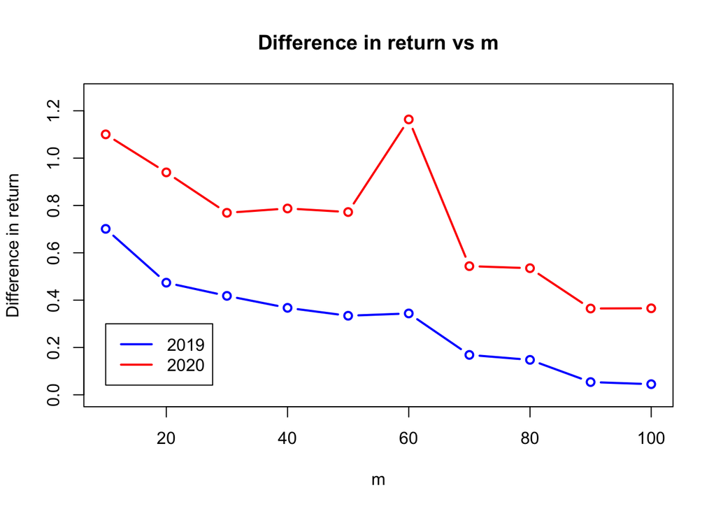

```r
plot(mlist,performance2019, type="b", col="blue", lwd=2, xlab="m", ylab="Difference in return", ylim=c(0,(max(performance2020)+0.1)))
lines(mlist, performance2020, type="b",col="red", lwd=2)
title("Difference in return vs m")
legend(10,0.3,c("2019","2020"), lwd=c(2,2), col=c("blue","red"))
```

*Analyze the performance of the portfolio for each value of m. How does the performance change? Is there some value of m, where there are diminishing returns of including more stocks in the portfolio?*

As m increases, the performance also increases in general. However, for 2020 data, there are some times, increasing m makes performance decreases (m=40 and 60). When m are at 70 and 90, there are diminishing returns of including more stocks in the portfolio.

*You can also look at the in-sample performance. That is, evaluate the performance in 2019 using 2019 portfolio construction and 2019 data. How is performance in 2019 different than performance in 2020? Why is it different?*

The performance in 2019 is always better than the performance in 2020. This is because we use 2019 data to construct the model and the performance in 2019 is in-sample, whereas the performance in 2020 is out-of-sample.

# Step 4

*Another way you could solve this problem is to completely ignore the stock selection IP and reformulate the weight selection problem to be an MIP that constrains the number of non-zero weights to be an integer.*

Objective:min Y1 + Y2 + … + Yt

Constraint: Y1 > Q1-sum(Wi * Ri1) –> Y1 + sum(Wi * Ri1) > Q1 Y1 > sum(Wi * Ri1)-Q1 –> Y1 - sum(Wi * Ri1) > -Q1 … Yt > Qt-sum(Wi * Rit) Yt > sum(Wi * Rit)-Qt

```r
# #Below is the Big M tecchnique required to solve the question
# library(gurobi)
# #timelimit = 3600
# t = nrow(return2019)
# n = ncol(return2019)-1
# M = 1
#
# performance2019 = c()
# performance2020 = c()
# mlist = c(5,seq(from = 10, to = n-1, by = 10),n)
# for (m in mlist){
#   print(m)
#   obj = c(rep(1,t),rep(0,n),rep(0,n)) # Y1,Y2,...,Yt; y1,y2,...,yn; w1,w2,...,wn
#   A = matrix(0,n+t*2+2,t+n*2)
#   b = matrix(0,n+t*2+2,1)
#   sense = rep('',n+t*2+2)
#
#   A[1,(t+1):(t+n)] = 1 # sum of y’s is equal to m
#   b[1,] = m
#   sense[1] = '='
#   #A[1,]
#
#   for (i in 1:n){
#     A[i+1,c(t+i,t+n+i)] = c(-M,1) # wi < Myi --> wi - Myi < 0
#     b[i+1,] = 0
#     sense[1+i] = '<'
#   }
#   #A[2,]
#
#   for (i in 1:t){ # Y1 + sum(Wi * Ri1) > Q1
#     A[1+n+i,i] = 1 #Yt
#     for (j in 1:n){
#       A[1+n+i,t+n+j] = return2019[i,j+1] # [row,col] -> [t,n] # Wi*Rit
#     }
#     b[1+n+i,] = return2019[i,1] # qt
#     sense[1+n+i] = '>'
#   }
#
#   for (i in 1:t){ # Y1 - sum(Wi * Ri1) > -Q1
#     A[1+n+t+i,i] = 1 #Yt
#     for (j in 1:n){
#       A[1+n+t+i,t+n+j] = -return2019[i,j+1] # [row,col] -> [t,n] # Wi*Rit
#     }
#     b[1+n+t+i,] = -return2019[i,1] # qt
#     sense[1+n+t+i] = '>'
#   }
#
#   A[1+n+t*2+1,(t+n+1):(t+n+n)] = 1 # sum(Wi) = 1
#   b[1+n+t*2+1,] = 1
#   sense[1+n+t*2+1] = '='
#
#
#   vtype = c(rep('C',t),rep('B',n),rep('C',n)) # C: continuous; B: binomial
#
#   model = list()
#   model$modelsense = 'min'
#   model$obj = obj
#   model$A = A
#   model$rhs = b
#   model$sense = sense
#   model$vtype = vtype
#
#   params = list()
#   params$TimeLimit = timelimit
#   params$outputflag = 0 # tell gurobi to shut the hell up!
#
#   invest.sol = gurobi(model,params = params)
#   #invest.sol$x
#   print(invest.sol$x[(t+1):(t+n)])
#   print(invest.sol$x[(t+n+1):(t+n+n)])
#   #print(invest.sol$objval)
#
#   cat('How well does this portfolio track the index in 2019? ',invest.sol$objval, '\n')
#   performance2019 = c(performance2019,invest.sol$objval)
#
#   # How well does this portfolio track the index in 2020?
#
#   mindiff2020 = sum(abs(return2020[,1] - data.matrix(return2020[,2:(n+1)]) %*% matrix(invest.sol$x[(t+n+1):(t+n+n)])))
#   cat('How well does this portfolio track the index in 2020? ',mindiff2020, '\n')
#   performance2020 = c(performance2020,mindiff2020)
# }
#
# #step4 = cbind(performance2019,performance2020)
# #write.csv(step4,'step4.csv')
```

```r
# plot(mlist,step4[,1], type="b", col="blue", lwd=2, xlab="m", ylab="Difference in return", ylim=c(0,(max(step4[,2])+0.1)))
# lines(mlist, step4[,2], type="b",col="red", lwd=2)
# title("Difference in return vs m")
# legend(80,0.8,c("2019","2020"), lwd=c(2,2), col=c("blue","red"))
```

```r
step4 = read.csv('step4.csv', header=T)
step4
```

```
##     X performance2019 performance2020
## 1   1      0.49925855       0.7773620
## 2   2      0.29013655       0.7533754
## 3   3      0.16257765       0.5123564
## 4   4      0.11113170       0.5160722
## 5   5      0.07940848       0.4135122
## 6   6      0.06095449       0.3920287
## 7   7      0.05180248       0.3766158
## 8   8      0.04748772       0.3605005
## 9   9      0.04522724       0.3706065
## 10 10      0.04491077       0.3686774
## 11 11      0.04491077       0.3686774
```

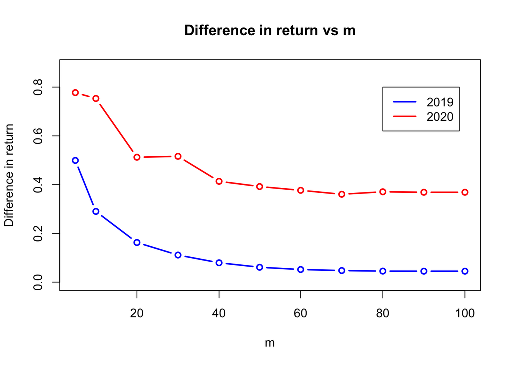

```r
n = ncol(return2019)-1
mlist = c(5,seq(from = 10, to = n-1, by = 10),n)
plot(mlist,step4[,2], type='b', col='blue', lwd=2, xlab='m', ylab='Difference in return', ylim=c(0,(max(step4[,3])+0.1)))
lines(mlist, step4[,3], type='b',col='red', lwd=2)
title('Difference in return vs m')
legend(80,0.8,c('2019','2020'), lwd=c(2,2), col=c('blue','red'))
```